# Part I - (201902-fordgobike-tripdata Dataset Exploration)

## Introduction

> This Project explores a dataset containing features of a bike hiring service including the information on durations made and a bit of info on the bike users.

> The exploration includes three stages

## a)Univariate Exploration

-What is the distribution of bike_share_for_all_trip -Whats the member_gender usage percentage -What are the types and distributuin of user_type -What are the differtent distributions of some of the numerical features -Which stations did the most trips start from?

## b)Bivariate Exploration

-What is the bike_share_for_all_trip for all the member_gender -What is the bike_share_for_all_trip for all the user_type -How is the user distribution on member_gender and user_type -Whats the correltaion between duration_sec for each member_gender -What is the bike_share_for_all_trip for the duration_sec -Whats the relation of bike_id with the duration_sec

## c)Multivariate Exploration

-what is the correltaion of all the features in the dataset -What is the correlation between duration_sec,member_gender and member_birth_year -What is the correlation between member_gender,duration_sec and user_type

## Preliminary Wrangling

```python
# import all packages and set plots to be embedded inline
import numpy as np
import pandas as pd
import matplotlib.pyplot as plt
import seaborn as sns

%matplotlib inline
```

> Load in your dataset and describe its properties through the questions below. Try and motivate your exploration goals through this section.

```python
# load in the dataset into a pandas dataframe
fordgobike = pd.read_csv('201902-fordgobike-tripdata.csv')
```

```python
# high-level overview of data shape and composition
print(fordgobike.shape)
print(fordgobike.dtypes)
fordgobike.head()
```

```
(183412, 16)
duration_sec                 int64
start_time                  object
end_time                    object
start_station_id           float64
start_station_name          object
start_station_latitude     float64
start_station_longitude    float64
end_station_id             float64
end_station_name            object
end_station_latitude       float64
end_station_longitude      float64
bike_id                      int64
user_type                   object
member_birth_year          float64
member_gender               object
bike_share_for_all_trip     object
dtype: object
```

|  | duration_sec | start_time | end_time | start_station_id | start_station_name | start_station_latitude | start_station_longitude | end_station_id | end_station_name | end_station_latitude | end_station_longitude | bike_id | user_type | member_birth_year | member_gender | bike_share_for_all_trip |
| --- | --- | --- | --- | --- | --- | --- | --- | --- | --- | --- | --- | --- | --- | --- | --- | --- |
| 0 | 52185 | 2019-02-28 17:32:10.1450 | 2019-03-01 08:01:55.9750 | 21.0 | Montgomery St BART Station (Market St at 2nd St) | 37.789625 | -122.400811 | 13.0 | Commercial St at Montgomery St | 37.794231 | -122.402923 | 4902 | Customer | 1984.0 | Male | No |
| 1 | 42521 | 2019-02-28 18:53:21.7890 | 2019-03-01 06:42:03.0560 | 23.0 | The Embarcadero at Steuart St | 37.791464 | -122.391034 | 81.0 | Berry St at 4th St | 37.775880 | -122.393170 | 2535 | Customer | NaN | NaN | No |
| 2 | 61854 | 2019-02-28 12:13:13.2180 | 2019-03-01 05:24:08.1460 | 86.0 | Market St at Dolores St | 37.769305 | -122.426826 | 3.0 | Powell St BART Station (Market St at 4th St) | 37.786375 | -122.404904 | 5905 | Customer | 1972.0 | Male | No |
| 3 | 36490 | 2019-02-28 17:54:26.0100 | 2019-03-01 04:02:36.8420 | 375.0 | Grove St at Masonic Ave | 37.774836 | -122.446546 | 70.0 | Central Ave at Fell St | 37.773311 | -122.444293 | 6638 | Subscriber | 1989.0 | Other | No |
| 4 | 1585 | 2019-02-28 23:54:18.5490 | 2019-03-01 00:20:44.0740 | 7.0 | Frank H Ogawa Plaza | 37.804562 | -122.271738 | 222.0 | 10th Ave at E 15th St | 37.792714 | -122.248780 | 4898 | Subscriber | 1974.0 | Male | Yes |

The dataset contains 183412 entries with 16 attributes.

```python
# descriptive statistics for numeric variables
print (fordgobike.describe())
print (fordgobike.info())
list(fordgobike)
```

```
        duration_sec  start_station_id  start_station_latitude  \
count  183412.000000     183215.000000           183412.000000
mean      726.078435        138.590427               37.771223
std      1794.389780        111.778864                0.099581
min        61.000000          3.000000               37.317298
25%       325.000000         47.000000               37.770083
50%       514.000000        104.000000               37.780760
75%       796.000000        239.000000               37.797280
max     85444.000000        398.000000               37.880222

       start_station_longitude  end_station_id  end_station_latitude  \
count            183412.000000   183215.000000         183412.000000
mean               -122.352664      136.249123             37.771427
std                   0.117097      111.515131              0.099490
min                -122.453704        3.000000             37.317298
25%                -122.412408       44.000000             37.770407
50%                -122.398285      100.000000             37.781010
75%                -122.286533      235.000000             37.797320
max                -121.874119      398.000000             37.880222

       end_station_longitude        bike_id  member_birth_year
count          183412.000000  183412.000000      175147.000000
mean             -122.352250    4472.906375        1984.806437
std                 0.116673    1664.383394          10.116689
min              -122.453704      11.000000        1878.000000
25%              -122.411726    3777.000000        1980.000000
50%              -122.398279    4958.000000        1987.000000
75%              -122.288045    5502.000000        1992.000000
max              -121.874119    6645.000000        2001.000000
<class 'pandas.core.frame.DataFrame'>
RangeIndex: 183412 entries, 0 to 183411
Data columns (total 16 columns):
duration_sec               183412 non-null int64
start_time                 183412 non-null object
end_time                   183412 non-null object
start_station_id           183215 non-null float64
start_station_name         183215 non-null object
start_station_latitude     183412 non-null float64
start_station_longitude    183412 non-null float64
end_station_id             183215 non-null float64
end_station_name           183215 non-null object
end_station_latitude       183412 non-null float64
end_station_longitude      183412 non-null float64
bike_id                    183412 non-null int64
user_type                  183412 non-null object
member_birth_year          175147 non-null float64
member_gender              175147 non-null object
bike_share_for_all_trip    183412 non-null object
dtypes: float64(7), int64(2), object(7)
memory usage: 22.4+ MB
None
```

```
['duration_sec',
 'start_time',
 'end_time',
 'start_station_id',
 'start_station_name',
 'start_station_latitude',
 'start_station_longitude',
 'end_station_id',
 'end_station_name',
 'end_station_latitude',
 'end_station_longitude',
 'bike_id',
 'user_type',
 'member_birth_year',
 'member_gender',
 'bike_share_for_all_trip']
```

Some features contain null variables.

```python
#Getting fetaures with objects
fordgobike.describe(include='object')
```

|  | start_time | end_time | start_station_name | end_station_name | user_type | member_gender | bike_share_for_all_trip |
| --- | --- | --- | --- | --- | --- | --- | --- |
| count | 183412 | 183412 | 183215 | 183215 | 183412 | 175147 | 183412 |
| unique | 183401 | 183397 | 329 | 329 | 2 | 3 | 2 |
| top | 2019-02-06 21:35:57.5740 | 2019-02-21 22:16:04.4780 | Market St at 10th St | San Francisco Caltrain Station 2 (Townsend St... | Subscriber | Male | No |
| freq | 2 | 2 | 3904 | 4857 | 163544 | 130651 | 166053 |

The member_gender column contains 3 types with the males being the most frequant gender .For the user type,subscribers seem to be the highest.Most trips ended at the San Francisco Caltrain Station 2 (Townsend St) station.From the above,we can conclude the dataset contains both numerical and categorical variables.

```python
fordgobike.isnull().sum()
```

```
duration_sec                  0
start_time                    0
end_time                      0
start_station_id            197
start_station_name          197
start_station_latitude        0
start_station_longitude       0
end_station_id              197
end_station_name            197
end_station_latitude          0
end_station_longitude         0
bike_id                       0
user_type                     0
member_birth_year          8265
member_gender              8265
bike_share_for_all_trip       0
dtype: int64
```

The start_station_id,start_station_name,end_station_id and end_station_name have 197 missing values while member_birth_year and member_gender have 8265 missing values

We are going to find the distinct categories in the bike_share_for_all_trip,member_gender and user_type features.

```python
fordgobike['bike_share_for_all_trip'].value_counts()
```

```
No     166053
Yes     17359
Name: bike_share_for_all_trip, dtype: int64
```

```python
fordgobike['member_gender'].value_counts()
```

```
Male      130651
Female     40844
Other       3652
Name: member_gender, dtype: int64
```

```python
fordgobike['user_type'].value_counts()
```

```
Subscriber    163544
Customer       19868
Name: user_type, dtype: int64
```

```python
fordgobike.dropna(subset = ['member_birth_year', 'member_gender'], inplace=True)
```

```python
fordgobike.isnull().sum()
```

```
duration_sec                 0
start_time                   0
end_time                     0
start_station_id           195
start_station_name         195
start_station_latitude       0
start_station_longitude      0
end_station_id             195
end_station_name           195
end_station_latitude         0
end_station_longitude        0
bike_id                      0
user_type                    0
member_birth_year            0
member_gender                0
bike_share_for_all_trip      0
dtype: int64
```

```python
#Create column for user's age and check for maximum and minimum age incase of outliers
fordgobike['member_age'] = 2022-fordgobike['member_birth_year'].astype('int')
fordgobike['member_age'].max()
```

```
144
```

```python
fordgobike['member_age'].min()
```

```
21
```

```python
fordgobike_age_outlier = fordgobike[fordgobike['member_age'] > 80]
fordgobike_age_outlier
```

|  | duration_sec | start_time | end_time | start_station_id | start_station_name | start_station_latitude | start_station_longitude | end_station_id | end_station_name | end_station_latitude | end_station_longitude | bike_id | user_type | member_birth_year | member_gender | bike_share_for_all_trip | member_age |
| --- | --- | --- | --- | --- | --- | --- | --- | --- | --- | --- | --- | --- | --- | --- | --- | --- | --- |
| 1285 | 148 | 2019-02-28 19:29:17.6270 | 2019-02-28 19:31:45.9670 | 158.0 | Shattuck Ave at Telegraph Ave | 37.833279 | -122.263490 | 173.0 | Shattuck Ave at 55th St | 37.840364 | -122.264488 | 5391 | Subscriber | 1900.0 | Male | Yes | 122 |
| 2085 | 694 | 2019-02-28 18:21:05.1870 | 2019-02-28 18:32:39.5960 | 107.0 | 17th St at Dolores St | 37.763015 | -122.426497 | 89.0 | Division St at Potrero Ave | 37.769218 | -122.407646 | 385 | Subscriber | 1941.0 | Male | No | 81 |
| 5197 | 217 | 2019-02-28 13:51:46.2380 | 2019-02-28 13:55:24.1270 | 70.0 | Central Ave at Fell St | 37.773311 | -122.444293 | 71.0 | Broderick St at Oak St | 37.773063 | -122.439078 | 5801 | Subscriber | 1931.0 | Male | No | 91 |
| 5266 | 384 | 2019-02-28 13:35:05.4280 | 2019-02-28 13:41:30.2230 | 84.0 | Duboce Park | 37.769201 | -122.433812 | 71.0 | Broderick St at Oak St | 37.773063 | -122.439078 | 6608 | Subscriber | 1931.0 | Male | No | 91 |
| 5447 | 147 | 2019-02-28 13:08:56.9350 | 2019-02-28 13:11:24.0620 | 84.0 | Duboce Park | 37.769201 | -122.433812 | 72.0 | Page St at Scott St | 37.772406 | -122.435650 | 5018 | Subscriber | 1931.0 | Male | No | 91 |
| 10827 | 1315 | 2019-02-27 19:21:34.4360 | 2019-02-27 19:43:30.0080 | 343.0 | Bryant St at 2nd St | 37.783172 | -122.393572 | 375.0 | Grove St at Masonic Ave | 37.774836 | -122.446546 | 6249 | Subscriber | 1900.0 | Male | No | 122 |
| 16087 | 1131 | 2019-02-27 08:37:36.8640 | 2019-02-27 08:56:28.0220 | 375.0 | Grove St at Masonic Ave | 37.774836 | -122.446546 | 36.0 | Folsom St at 3rd St | 37.783830 | -122.398870 | 4968 | Subscriber | 1900.0 | Male | No | 122 |
| 17981 | 366 | 2019-02-26 19:53:38.5280 | 2019-02-26 19:59:44.9680 | 50.0 | 2nd St at Townsend St | 37.780526 | -122.390288 | 21.0 | Montgomery St BART Station (Market St at 2nd St) | 37.789625 | -122.400811 | 5226 | Subscriber | 1920.0 | Male | No | 102 |
| 18560 | 578 | 2019-02-26 18:17:31.2900 | 2019-02-26 18:27:09.3070 | 58.0 | Market St at 10th St | 37.776619 | -122.417385 | 89.0 | Division St at Potrero Ave | 37.769218 | -122.407646 | 183 | Subscriber | 1941.0 | Male | No | 81 |
| 18885 | 432 | 2019-02-26 17:48:59.0160 | 2019-02-26 17:56:11.3700 | 21.0 | Montgomery St BART Station (Market St at 2nd St) | 37.789625 | -122.400811 | 50.0 | 2nd St at Townsend St | 37.780526 | -122.390288 | 5319 | Subscriber | 1920.0 | Male | No | 102 |
| 19375 | 641 | 2019-02-26 17:03:19.8550 | 2019-02-26 17:14:01.6190 | 9.0 | Broadway at Battery St | 37.798572 | -122.400869 | 30.0 | San Francisco Caltrain (Townsend St at 4th St) | 37.776598 | -122.395282 | 6164 | Customer | 1900.0 | Male | No | 122 |
| 20743 | 380 | 2019-02-26 10:57:07.7670 | 2019-02-26 11:03:28.1960 | 26.0 | 1st St at Folsom St | 37.787290 | -122.394380 | 61.0 | Howard St at 8th St | 37.776513 | -122.411306 | 5387 | Subscriber | 1933.0 | Female | Yes | 89 |
| 21424 | 1424 | 2019-02-26 08:58:02.9040 | 2019-02-26 09:21:47.7490 | 375.0 | Grove St at Masonic Ave | 37.774836 | -122.446546 | 343.0 | Bryant St at 2nd St | 37.783172 | -122.393572 | 5344 | Subscriber | 1900.0 | Male | No | 122 |
| 21506 | 701 | 2019-02-26 09:06:11.2390 | 2019-02-26 09:17:52.4420 | 67.0 | San Francisco Caltrain Station 2 (Townsend St... | 37.776639 | -122.395526 | 9.0 | Broadway at Battery St | 37.798572 | -122.400869 | 5337 | Customer | 1900.0 | Male | No | 122 |
| 24042 | 194 | 2019-02-25 18:58:10.6440 | 2019-02-25 19:01:25.3080 | 158.0 | Shattuck Ave at Telegraph Ave | 37.833279 | -122.263490 | 173.0 | Shattuck Ave at 55th St | 37.840364 | -122.264488 | 6363 | Subscriber | 1900.0 | Male | Yes | 122 |
| 26133 | 410 | 2019-02-25 13:38:12.0670 | 2019-02-25 13:45:02.2070 | 173.0 | Shattuck Ave at 55th St | 37.840364 | -122.264488 | 176.0 | MacArthur BART Station | 37.828410 | -122.266315 | 3311 | Subscriber | 1900.0 | Male | Yes | 122 |
| 26344 | 534 | 2019-02-25 12:43:50.2250 | 2019-02-25 12:52:45.1280 | 26.0 | 1st St at Folsom St | 37.787290 | -122.394380 | 61.0 | Howard St at 8th St | 37.776513 | -122.411306 | 5948 | Subscriber | 1933.0 | Female | Yes | 89 |
| 26488 | 334 | 2019-02-25 12:13:25.3300 | 2019-02-25 12:18:59.4340 | 71.0 | Broderick St at Oak St | 37.773063 | -122.439078 | 84.0 | Duboce Park | 37.769201 | -122.433812 | 3361 | Subscriber | 1931.0 | Male | No | 91 |
| 26535 | 119 | 2019-02-25 12:08:38.3110 | 2019-02-25 12:10:37.6600 | 71.0 | Broderick St at Oak St | 37.773063 | -122.439078 | 53.0 | Grove St at Divisadero | 37.775946 | -122.437777 | 6475 | Subscriber | 1931.0 | Male | No | 91 |
| 26568 | 135 | 2019-02-25 12:02:18.3600 | 2019-02-25 12:04:34.2720 | 71.0 | Broderick St at Oak St | 37.773063 | -122.439078 | 53.0 | Grove St at Divisadero | 37.775946 | -122.437777 | 6257 | Subscriber | 1931.0 | Male | No | 91 |
| 26604 | 294 | 2019-02-25 11:52:12.5370 | 2019-02-25 11:57:06.9850 | 85.0 | Church St at Duboce Ave | 37.770083 | -122.429156 | 53.0 | Grove St at Divisadero | 37.775946 | -122.437777 | 5814 | Subscriber | 1931.0 | Male | No | 91 |
| 26641 | 78 | 2019-02-25 11:50:14.7770 | 2019-02-25 11:51:33.5550 | 85.0 | Church St at Duboce Ave | 37.770083 | -122.429156 | 85.0 | Church St at Duboce Ave | 37.770083 | -122.429156 | 4361 | Subscriber | 1931.0 | Male | No | 91 |
| 26685 | 110 | 2019-02-25 11:40:27.3480 | 2019-02-25 11:42:17.7820 | 85.0 | Church St at Duboce Ave | 37.770083 | -122.429156 | 73.0 | Pierce St at Haight St | 37.771793 | -122.433708 | 6208 | Subscriber | 1931.0 | Male | No | 91 |
| 26718 | 138 | 2019-02-25 11:33:27.1720 | 2019-02-25 11:35:45.1760 | 71.0 | Broderick St at Oak St | 37.773063 | -122.439078 | 73.0 | Pierce St at Haight St | 37.771793 | -122.433708 | 6110 | Subscriber | 1931.0 | Male | No | 91 |
| 26757 | 81 | 2019-02-25 11:25:52.7530 | 2019-02-25 11:27:14.7060 | 375.0 | Grove St at Masonic Ave | 37.774836 | -122.446546 | 70.0 | Central Ave at Fell St | 37.773311 | -122.444293 | 579 | Subscriber | 1931.0 | Male | No | 91 |
| 26775 | 130 | 2019-02-25 11:21:03.4690 | 2019-02-25 11:23:13.5690 | 71.0 | Broderick St at Oak St | 37.773063 | -122.439078 | 70.0 | Central Ave at Fell St | 37.773311 | -122.444293 | 5354 | Subscriber | 1931.0 | Male | No | 91 |
| 26807 | 116 | 2019-02-25 11:14:28.4370 | 2019-02-25 11:16:25.2620 | 375.0 | Grove St at Masonic Ave | 37.774836 | -122.446546 | 70.0 | Central Ave at Fell St | 37.773311 | -122.444293 | 74 | Subscriber | 1931.0 | Male | No | 91 |
| 26828 | 139 | 2019-02-25 11:08:41.6020 | 2019-02-25 11:11:01.5590 | 71.0 | Broderick St at Oak St | 37.773063 | -122.439078 | 70.0 | Central Ave at Fell St | 37.773311 | -122.444293 | 1428 | Subscriber | 1931.0 | Male | No | 91 |
| 26906 | 82 | 2019-02-25 10:54:23.3210 | 2019-02-25 10:55:45.9020 | 85.0 | Church St at Duboce Ave | 37.770083 | -122.429156 | 86.0 | Market St at Dolores St | 37.769305 | -122.426826 | 1916 | Subscriber | 1931.0 | Male | No | 91 |
| 26917 | 67 | 2019-02-25 10:51:02.3820 | 2019-02-25 10:52:09.3940 | 85.0 | Church St at Duboce Ave | 37.770083 | -122.429156 | 86.0 | Market St at Dolores St | 37.769305 | -122.426826 | 2664 | Subscriber | 1931.0 | Male | No | 91 |
| ... | ... | ... | ... | ... | ... | ... | ... | ... | ... | ... | ... | ... | ... | ... | ... | ... | ... |
| 144039 | 378 | 2019-02-07 13:24:05.8330 | 2019-02-07 13:30:23.9470 | 26.0 | 1st St at Folsom St | 37.787290 | -122.394380 | 349.0 | Howard St at Mary St | 37.781010 | -122.405666 | 5485 | Subscriber | 1933.0 | Female | Yes | 89 |
| 145215 | 509 | 2019-02-07 09:59:33.8220 | 2019-02-07 10:08:03.4800 | 349.0 | Howard St at Mary St | 37.781010 | -122.405666 | 27.0 | Beale St at Harrison St | 37.788059 | -122.391865 | 4811 | Subscriber | 1933.0 | Female | Yes | 89 |
| 145510 | 508 | 2019-02-07 09:34:11.5420 | 2019-02-07 09:42:40.4000 | 30.0 | San Francisco Caltrain (Townsend St at 4th St) | 37.776598 | -122.395282 | 26.0 | 1st St at Folsom St | 37.787290 | -122.394380 | 5541 | Subscriber | 1902.0 | Female | No | 120 |
| 147519 | 460 | 2019-02-07 07:44:28.2170 | 2019-02-07 07:52:08.3900 | 284.0 | Yerba Buena Center for the Arts (Howard St at ... | 37.784872 | -122.400876 | 30.0 | San Francisco Caltrain (Townsend St at 4th St) | 37.776598 | -122.395282 | 3646 | Subscriber | 1901.0 | Male | No | 121 |
| 149706 | 370 | 2019-02-06 18:58:13.9340 | 2019-02-06 19:04:24.9120 | 118.0 | Eureka Valley Recreation Center | 37.759177 | -122.436943 | 84.0 | Duboce Park | 37.769201 | -122.433812 | 5334 | Subscriber | 1931.0 | Male | No | 91 |
| 150108 | 727 | 2019-02-06 18:24:40.3100 | 2019-02-06 18:36:48.1830 | 81.0 | Berry St at 4th St | 37.775880 | -122.393170 | 284.0 | Yerba Buena Center for the Arts (Howard St at ... | 37.784872 | -122.400876 | 5356 | Subscriber | 1910.0 | Other | No | 112 |
| 151936 | 622 | 2019-02-06 16:42:11.9280 | 2019-02-06 16:52:34.2300 | 25.0 | Howard St at 2nd St | 37.787522 | -122.397405 | 30.0 | San Francisco Caltrain (Townsend St at 4th St) | 37.776598 | -122.395282 | 560 | Subscriber | 1902.0 | Female | No | 120 |
| 152627 | 2339 | 2019-02-06 14:43:11.1750 | 2019-02-06 15:22:10.7250 | 11.0 | Davis St at Jackson St | 37.797280 | -122.398436 | 11.0 | Davis St at Jackson St | 37.797280 | -122.398436 | 2650 | Subscriber | 1941.0 | Male | No | 81 |
| 152842 | 5855 | 2019-02-06 12:58:59.7870 | 2019-02-06 14:36:35.4620 | 11.0 | Davis St at Jackson St | 37.797280 | -122.398436 | 11.0 | Davis St at Jackson St | 37.797280 | -122.398436 | 1052 | Subscriber | 1941.0 | Male | No | 81 |
| 153357 | 892 | 2019-02-06 12:44:32.6590 | 2019-02-06 12:59:24.8640 | 88.0 | 11th St at Bryant St | 37.770030 | -122.411726 | 131.0 | 22nd St at Dolores St | 37.755000 | -122.425728 | 4400 | Subscriber | 1938.0 | Male | No | 84 |
| 153746 | 331 | 2019-02-06 11:48:52.0910 | 2019-02-06 11:54:23.6530 | 127.0 | Valencia St at 21st St | 37.756708 | -122.421025 | 110.0 | 17th & Folsom Street Park (17th St at Folsom St) | 37.763708 | -122.415204 | 5112 | Subscriber | 1938.0 | Male | No | 84 |
| 157035 | 335 | 2019-02-06 06:36:44.4810 | 2019-02-06 06:42:20.3080 | 84.0 | Duboce Park | 37.769201 | -122.433812 | 118.0 | Eureka Valley Recreation Center | 37.759177 | -122.436943 | 3303 | Subscriber | 1931.0 | Male | No | 91 |
| 158882 | 645 | 2019-02-05 18:30:58.8410 | 2019-02-05 18:41:43.8600 | 58.0 | Market St at 10th St | 37.776619 | -122.417385 | 89.0 | Division St at Potrero Ave | 37.769218 | -122.407646 | 2741 | Subscriber | 1941.0 | Male | No | 81 |
| 159405 | 584 | 2019-02-05 17:59:16.2440 | 2019-02-05 18:09:00.9400 | 26.0 | 1st St at Folsom St | 37.787290 | -122.394380 | 5.0 | Powell St BART Station (Market St at 5th St) | 37.783899 | -122.408445 | 5098 | Subscriber | 1933.0 | Female | Yes | 89 |
| 161505 | 355 | 2019-02-05 14:43:59.2270 | 2019-02-05 14:49:54.2670 | 25.0 | Howard St at 2nd St | 37.787522 | -122.397405 | 30.0 | San Francisco Caltrain (Townsend St at 4th St) | 37.776598 | -122.395282 | 4928 | Subscriber | 1902.0 | Female | No | 120 |
| 162051 | 176 | 2019-02-05 13:00:00.6040 | 2019-02-05 13:02:57.5490 | 173.0 | Shattuck Ave at 55th St | 37.840364 | -122.264488 | 174.0 | Shattuck Ave at 51st St | 37.836801 | -122.264004 | 2442 | Subscriber | 1900.0 | Male | Yes | 122 |
| 163112 | 1640 | 2019-02-05 09:18:18.3970 | 2019-02-05 09:45:39.0160 | 377.0 | Fell St at Stanyan St | 37.771917 | -122.453704 | 36.0 | Folsom St at 3rd St | 37.783830 | -122.398870 | 2715 | Subscriber | 1900.0 | Male | No | 122 |
| 165505 | 255 | 2019-02-05 06:52:54.1940 | 2019-02-05 06:57:10.0830 | 84.0 | Duboce Park | 37.769201 | -122.433812 | 118.0 | Eureka Valley Recreation Center | 37.759177 | -122.436943 | 5381 | Subscriber | 1931.0 | Male | No | 91 |
| 167178 | 526 | 2019-02-04 17:36:54.1550 | 2019-02-04 17:45:41.1400 | 25.0 | Howard St at 2nd St | 37.787522 | -122.397405 | 30.0 | San Francisco Caltrain (Townsend St at 4th St) | 37.776598 | -122.395282 | 184 | Subscriber | 1902.0 | Female | No | 120 |
| 171086 | 1086 | 2019-02-04 06:30:33.3830 | 2019-02-04 06:48:39.8690 | 375.0 | Grove St at Masonic Ave | 37.774836 | -122.446546 | 36.0 | Folsom St at 3rd St | 37.783830 | -122.398870 | 4435 | Subscriber | 1900.0 | Male | No | 122 |
| 171757 | 94 | 2019-02-03 19:12:06.6070 | 2019-02-03 19:13:40.6710 | 173.0 | Shattuck Ave at 55th St | 37.840364 | -122.264488 | 174.0 | Shattuck Ave at 51st St | 37.836801 | -122.264004 | 4539 | Subscriber | 1900.0 | Male | Yes | 122 |
| 171996 | 1368 | 2019-02-03 17:33:54.6070 | 2019-02-03 17:56:42.9490 | 37.0 | 2nd St at Folsom St | 37.785000 | -122.395936 | 375.0 | Grove St at Masonic Ave | 37.774836 | -122.446546 | 4988 | Subscriber | 1900.0 | Male | No | 122 |
| 173711 | 993 | 2019-02-03 09:45:30.4640 | 2019-02-03 10:02:04.1690 | 375.0 | Grove St at Masonic Ave | 37.774836 | -122.446546 | 36.0 | Folsom St at 3rd St | 37.783830 | -122.398870 | 5445 | Subscriber | 1900.0 | Male | No | 122 |
| 175394 | 1310 | 2019-02-02 14:17:10.2320 | 2019-02-02 14:39:00.4120 | 85.0 | Church St at Duboce Ave | 37.770083 | -122.429156 | 89.0 | Division St at Potrero Ave | 37.769218 | -122.407646 | 5125 | Customer | 1939.0 | Male | No | 83 |
| 177708 | 1527 | 2019-02-01 19:09:28.3870 | 2019-02-01 19:34:55.9630 | 343.0 | Bryant St at 2nd St | 37.783172 | -122.393572 | 375.0 | Grove St at Masonic Ave | 37.774836 | -122.446546 | 5286 | Subscriber | 1900.0 | Male | No | 122 |
| 177885 | 517 | 2019-02-01 18:38:40.4710 | 2019-02-01 18:47:18.3920 | 25.0 | Howard St at 2nd St | 37.787522 | -122.397405 | 30.0 | San Francisco Caltrain (Townsend St at 4th St) | 37.776598 | -122.395282 | 2175 | Subscriber | 1902.0 | Female | No | 120 |
| 177955 | 377 | 2019-02-01 18:23:33.4110 | 2019-02-01 18:29:50.7950 | 26.0 | 1st St at Folsom St | 37.787290 | -122.394380 | 321.0 | 5th St at Folsom | 37.780146 | -122.403071 | 5444 | Subscriber | 1933.0 | Female | Yes | 89 |
| 179280 | 355 | 2019-02-01 14:32:42.2470 | 2019-02-01 14:38:37.8960 | 134.0 | Valencia St at 24th St | 37.752428 | -122.420628 | 131.0 | 22nd St at Dolores St | 37.755000 | -122.425728 | 1815 | Subscriber | 1938.0 | Male | No | 84 |
| 182830 | 428 | 2019-02-01 07:45:05.9340 | 2019-02-01 07:52:14.9220 | 284.0 | Yerba Buena Center for the Arts (Howard St at ... | 37.784872 | -122.400876 | 67.0 | San Francisco Caltrain Station 2 (Townsend St... | 37.776639 | -122.395526 | 5031 | Subscriber | 1901.0 | Male | No | 121 |
| 183388 | 490 | 2019-02-01 00:39:53.1120 | 2019-02-01 00:48:03.3380 | 61.0 | Howard St at 8th St | 37.776513 | -122.411306 | 81.0 | Berry St at 4th St | 37.775880 | -122.393170 | 5411 | Subscriber | 1927.0 | Male | No | 95 |

212 rows × 17 columns

```python
#drop the outlier  rows
fordgobike_1= fordgobike.drop(fordgobike_age_outlier.index, axis=0)
```

```python
print(fordgobike_1.shape)
```

```
(174935, 17)
```

```python
#Converting the start and en time columns to date and time stamp
fordgobike_1['start_time'] = pd.to_datetime(fordgobike_1['start_time'])
fordgobike_1['end_time'] = pd.to_datetime(fordgobike_1['end_time'])
```

```python
print(fordgobike_1.dtypes)
```

```
duration_sec                        int64
start_time                 datetime64[ns]
end_time                   datetime64[ns]
start_station_id                  float64
start_station_name                 object
start_station_latitude            float64
start_station_longitude           float64
end_station_id                    float64
end_station_name                   object
end_station_latitude              float64
end_station_longitude             float64
bike_id                             int64
user_type                          object
member_birth_year                 float64
member_gender                      object
bike_share_for_all_trip            object
member_age                          int64
dtype: object
```

### What is/are the main feature(s) of interest in your dataset?

I'm most interested in figuring out what features contribute the most in bike hiring in the dataset. Such as time taken for each trip(duration in sec),member gender,member age

### What features in the dataset do you think will help support your investigation into your feature(s) of interest?

I expect that subscibers will have the highest number of biker hirers.I also expect there be a higher number of users with bike share for all trips.Some features that would include;member_birth_year,user_type,bike_share_for_all_trip and member_gender

## Univariate Exploration

> In this section, investigate distributions of individual variables. If you see unusual points or outliers, take a deeper look to clean things up and prepare yourself to look at relationships between variables.

> **Rubric Tip**: The project (Parts I alone) should have at least 15 visualizations distributed over univariate, bivariate, and multivariate plots to explore many relationships in the data set. Use reasoning to justify the flow of the exploration.

> **Rubric Tip**: Use the "Question-Visualization-Observations" framework throughout the exploration. This framework involves **asking a question from the data, creating a visualization to find answers, and then recording observations after each visualisation.**

## The first feature of interest was checking the bike_share_for_all_trip distribution

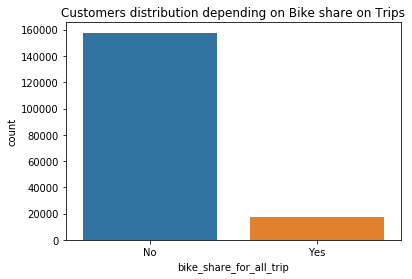

```python
sns.countplot(fordgobike_1['bike_share_for_all_trip'])
plt.title("Customers distribution depending on Bike share on Trips")

plt.show()
```

160,000 people in the datset who hired bikes were not awareded any bikeshares for any trip they made.However,only 20,000 were awarded.There seems to be a determining factor that qualifies one for the bike share for any trip made.

## The second Feature of interest was member_gender

```
Text(0.5,1,'Member Gender Distribution')
```

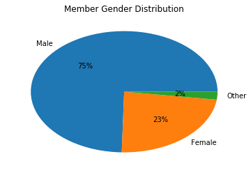

```python
df=fordgobike_1['member_gender'].value_counts()
plt.pie(df, labels=df.index, autopct="%.0f%%");
plt.title("Member Gender Distribution")
```

3652 which contributes to 2% of the datset dont have a defined gender.However,we can tell males hire the bikes more with a usage of 75% compared to females who are at 23%.

## The third feature of interest was user_type.

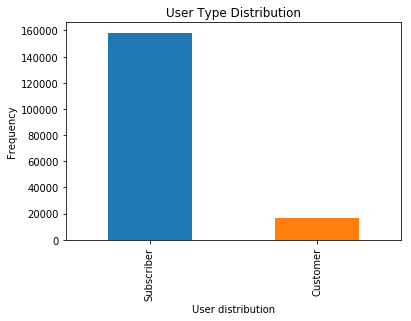

```python
fordgobike_1['user_type'].value_counts().head(10).plot.bar()
plt.xlabel('User distribution')
plt.ylabel('Frequency')
plt.title("User Type Distribution")

plt.show()
```

There seems to bea higher number of subscibers than customers in the dataset.This would probably mean most of the people hiring the bikes are consistent people comoared to people who rarely hire the bikes in the dataset.

## The fourth features was getting the differtent distributions of some of the numerical features in the dataset

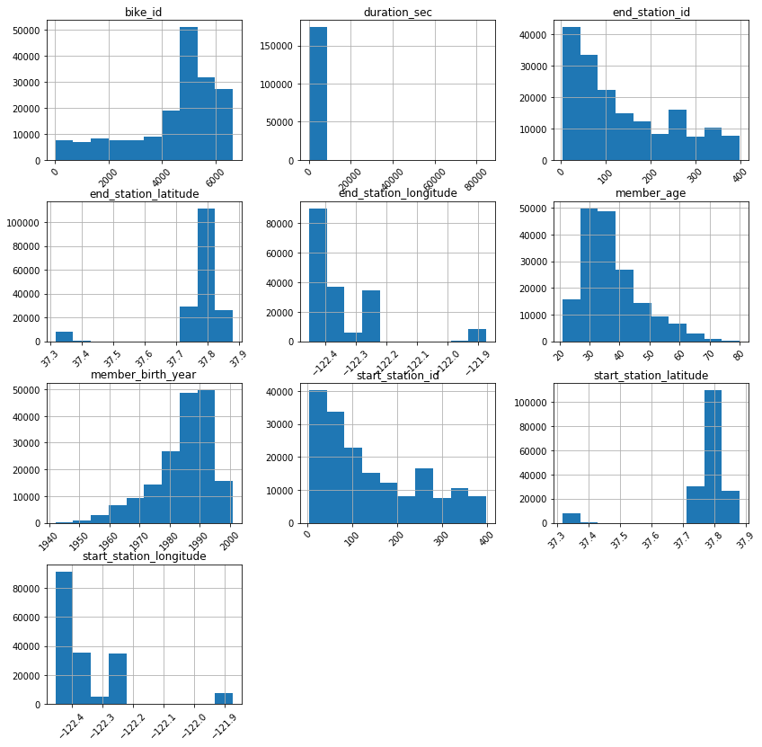

```python
fordgobike_1.hist(figsize=(14,14), xrot=45)
plt.show()
```

## The fifth feature was the start_station_name.

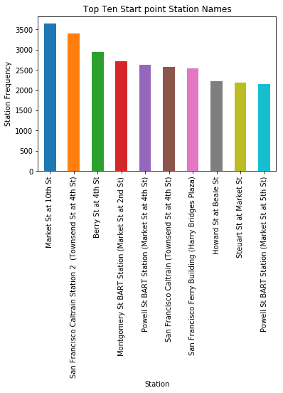

```python
fordgobike_1['start_station_name'].value_counts().head(10).plot.bar()
plt.xlabel('Station')
plt.ylabel('Station Frequency')
plt.title("Top Ten Start point Station Names")

plt.show()
```

I decided to just plot the first 10 start stations as there were to many .We can tell most trips started from Market St 10th street with above 3500 trips starting from the station.

### Discuss the distribution(s) of your variable(s) of interest. Were there any unusual points? Did you need to perform any transformations?

> Some cleanup was necessary for this dataset. The earlier cleaning included changing data types, such as time and date, and removing some ages that were more than 80 years old (not very likely to be valid).

### Of the features you investigated, were there any unusual distributions? Did you perform any operations on the data to tidy, adjust, or change the form of the data? If so, why did you do this?

> The fact that no rider would be 144 years old indicates that some of the birth years were wrong. Additionally, I deleted the information from any rows that lacked a gender or age.

## Bivariate Exploration

> In this section, investigate relationships between pairs of variables in your data. Make sure the variables that you cover here have been introduced in some fashion in the previous section (univariate exploration).

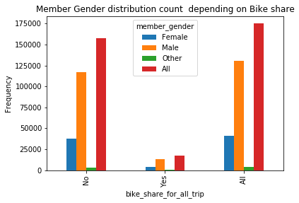

```python
fordgobike_realation_1=pd.crosstab(index=fordgobike_1['bike_share_for_all_trip'], columns=fordgobike_1['member_gender'], margins=True)
fordgobike_realation_1.head(10).plot.bar()
plt.ylabel('Frequency')
plt.title("Member Gender distribution count  depending on Bike share")

plt.show()
```

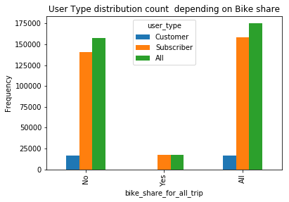

```python
fordgobike_realation_1=pd.crosstab(index=fordgobike_1['bike_share_for_all_trip'], columns=fordgobike_1['user_type'], margins=True)
fordgobike_realation_1.head(10).plot.bar()
plt.ylabel('Frequency')
plt.title("User Type distribution count  depending on Bike share")

plt.show()
```

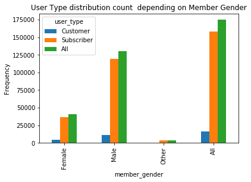

```python
fordgobike_realation_1=pd.crosstab(index=fordgobike_1['member_gender'], columns=fordgobike_1['user_type'], margins=True)
fordgobike_realation_1.head(10).plot.bar()
plt.ylabel('Frequency')
plt.title("User Type distribution count  depending on Member Gender")

plt.show()
```

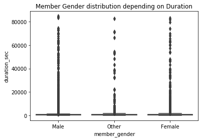

```python
sns.boxplot(data=fordgobike_1, x='member_gender', y='duration_sec')
plt.title("Member Gender distribution depending on Duration")

plt.show()
```

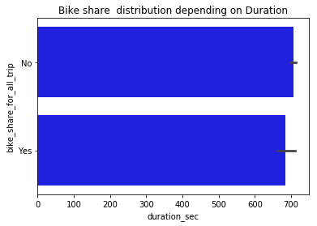

```python
sns.barplot(
    x='duration_sec',
    y='bike_share_for_all_trip',
    data=fordgobike_1,
    color='blue')
plt.title("Bike share  distribution depending on Duration")

plt.show()
```

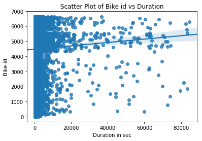

```python
sns.regplot(data = fordgobike_1, x = 'duration_sec', y = 'bike_id');
plt.xlabel('Duration in sec')
plt.ylabel('Bike id')
plt.title("Scatter Plot of Bike id vs Duration")

plt.show()
```

### Did you observe any interesting relationships between the other features (not the main feature(s) of interest)?

> It s intriguing to see the females almost matching the duration time of males

## Multivariate Exploration

> Create plots of three or more variables to investigate your data even further. Make sure that your investigations are justified, and follow from your work in the previous sections.

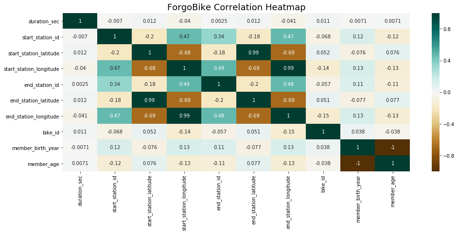

```python
#Creating an annotated heatmap showcasing the correlation between the columns
plt.figure(figsize=(16, 6))
heatmap = sns.heatmap(fordgobike_1.corr(), vmin=-1, vmax=1, annot=True, cmap='BrBG')
heatmap.set_title('ForgoBike Correlation Heatmap', fontdict={'fontsize':18});
```

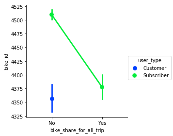

```python
sns.factorplot(
    x='bike_share_for_all_trip',
    y='bike_id',
    data=fordgobike_1,
    palette='bright',
    kind='point',
    hue='user_type',
    title='User type vs Bikeshare plot based on the Bike id');
```

[figure not shown]

```python
fig = plt.figure(figsize = [8,6])
ax = sns.pointplot(data = fordgobike_1, x ='duration_sec', y = 'member_birth_year', hue = 'member_gender',
           palette = 'colorblind', linestyles = '', dodge = 0.4)
plt.title('Member Birth Year vs Duration in Sec')
plt.ylabel('member_birth_year')
ax.set_yticklabels([],minor = True)
plt.show();
```

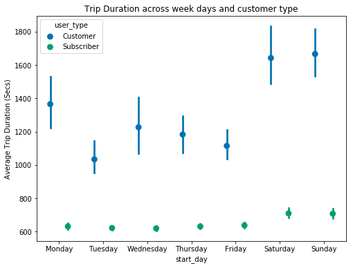

```python
import datetime as dt
fordgobike_1['start_day'] = fordgobike_1['start_time'].dt.day_name()

# convert day, and hour into ordered categorical types
ordinal_var_dict = {'start_day': ['Monday','Tuesday','Wednesday','Thursday','Friday', 'Saturday', 'Sunday']}

for var in ordinal_var_dict:
    ordered_var = pd.api.types.CategoricalDtype(ordered = True,
                                                categories = ordinal_var_dict[var])
    fordgobike_1[var] = fordgobike_1[var].astype(ordered_var)

fig = plt.figure(figsize = [8,6])
ax = sns.pointplot(data = fordgobike_1, x ='start_day', y = 'duration_sec', hue = 'user_type',
           palette = 'colorblind', linestyles = '', dodge = 0.4)
plt.title('Trip Duration across week days and customer type')
plt.ylabel('Trip Duration (Secs)')
ax.set_yticklabels([],minor = True)
plt.show();
```

## Conclusions

> Most users were Male. Most users were subscriber. More subscribers got more bike shares compared to the customers

> Remove all Tips mentioned above, before you convert this notebook to PDF/HTML

> At the end of your report, make sure that you export the notebook as an html file from the `File > Download as... > HTML or PDF` menu. Make sure you keep track of where the exported file goes, so you can put it in the same folder as this notebook for project submission. Also, make sure you remove all of the quote-formatted guide notes like this one before you finish your report!